# R Notebook

Christian Diener cdiener@systemsbiology.org

# Effect of duration length

## Data preparation

We will start by reading our data and required libraries.

```r
library(mbtools)
theme_set(theme_bw())

ps <- readRDS("data/duration_exp.rds")

total <- subset_samples(ps, Spore == 0)

# used to keep track of the raw data for the figures
fig_data <- list()
```

We sill start by building up a dataframe that combines phyla abundances and sample metadata.

```r
phyla <- taxa_count(total, "Phylum")

sdata <- as.data.table(as(sample_data(total), "data.frame"))
phyla <- phyla[sdata, on = c(sample = "Description")]
head(phyla)
```

| sample | taxa | reads | SampleID | Mouse | GroupSpore | GroupCat | Group | DateCat | EpochDateCat | EpochDate | SporeCat | Spore | DayCat | Day | GroupDay | GroupSporeDay | Response | ResponseDay | GroupSporeResponseDay | duration | TimepointCat |
| --- | --- | --- | --- | --- | --- | --- | --- | --- | --- | --- | --- | --- | --- | --- | --- | --- | --- | --- | --- | --- | --- |
| 0A-03-03-16 | Actinobacteria | 3 | 0A.d-1.total | 0A | 00.total | 0 | 0 | 3/3/16 | 16863 | 16863 | total | 0 | -1 | -1 | 00.d-1 | 00.total.d-1 | control | cnt.d-1 | 00.total.cnt.d-1 | 0 | before |
| 0A-03-03-16 | Bacteroidetes | 7154 | 0A.d-1.total | 0A | 00.total | 0 | 0 | 3/3/16 | 16863 | 16863 | total | 0 | -1 | -1 | 00.d-1 | 00.total.d-1 | control | cnt.d-1 | 00.total.cnt.d-1 | 0 | before |
| 0A-03-03-16 | Cyanobacteria | 7 | 0A.d-1.total | 0A | 00.total | 0 | 0 | 3/3/16 | 16863 | 16863 | total | 0 | -1 | -1 | 00.d-1 | 00.total.d-1 | control | cnt.d-1 | 00.total.cnt.d-1 | 0 | before |
| 0A-03-03-16 | Firmicutes | 4935 | 0A.d-1.total | 0A | 00.total | 0 | 0 | 3/3/16 | 16863 | 16863 | total | 0 | -1 | -1 | 00.d-1 | 00.total.d-1 | control | cnt.d-1 | 00.total.cnt.d-1 | 0 | before |
| 0A-03-03-16 | Proteobacteria | 61 | 0A.d-1.total | 0A | 00.total | 0 | 0 | 3/3/16 | 16863 | 16863 | total | 0 | -1 | -1 | 00.d-1 | 00.total.d-1 | control | cnt.d-1 | 00.total.cnt.d-1 | 0 | before |
| 0A-03-03-16 | Tenericutes | 831 | 0A.d-1.total | 0A | 00.total | 0 | 0 | 3/3/16 | 16863 | 16863 | total | 0 | -1 | -1 | 00.d-1 | 00.total.d-1 | control | cnt.d-1 | 00.total.cnt.d-1 | 0 | before |

```r
fig_data[["Fig. 1B"]] <- phyla
```

# Phyla abundances

## By duration

First we have to assemble the relative abundances for controls.

```r
control <- phyla[duration == 0]
control[, relative := reads / sum(reads, na.rm = T)]

high_taxa <- phyla[Day - duration == 0,
                   .(taxa, rel = reads / sum(reads)),
                   by = "sample"][rel > 1e-3, unique(taxa)]
```

We will plot a reference bar chart for those, removing all phyla that contribute less than 0.1% of the total reads.

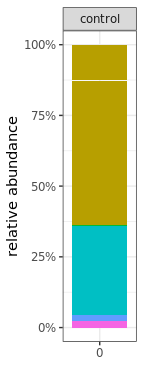

```r
pl <- ggplot(control[taxa %in% high_taxa],
             aes(x = factor(duration), y = relative, fill = taxa)) +
  geom_bar(stat = "identity") + scale_y_continuous(labels = scales::percent) +
  theme_bw() +
  labs(x = "antibiotic duration [days]", y = "relative abundance") +
  facet_wrap(~ Response) + guides(fill = "none") + labs(x = "")
ggsave("figures/control_duration.png", height = 4, width = 1.5, dpi = 300)
pl
```

Now we will do the same thing for the non-responders and responders.

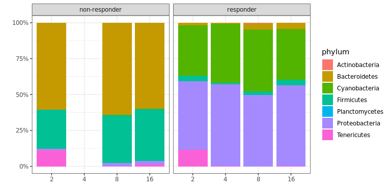

```r
treated <- phyla[duration > 0 & Day - duration == 0]
treated[, relative := reads / sum(reads), by = c("duration", "Response")]

pl <- ggplot(treated[taxa %in% high_taxa],
             aes(x = factor(duration), y = relative, fill = taxa)) +
  geom_bar(stat = "identity") + scale_y_continuous(labels = scales::percent) +
  facet_wrap(~ Response) + theme_bw() +
  labs(x = "", y = "", fill = "phylum")
ggsave("figures/treatment_duration.png", height = 4, width = 8, dpi = 300)
pl
```